# Overview

# forest

Modelling with a large number of decision trees.

```r
library(randomForest)
df.forest <- randomForest(form,data=train_df)

ypred <- predict(df.forest, newdata = test_df)
mae(ypred, actual)
```

```
## [1] 6.832096
```

```r
hyper_grid <- expand.grid( mtry = 2:5, splitrule = c('extratrees'), min.node.size = c(1,3,5))
fit.rf <- train( form, data = train_df, method='ranger',
                 trControl = fitControl, tuneGrid = hyper_grid)

pred.rf <- predict(fit.rf, newdata =test_df)
```

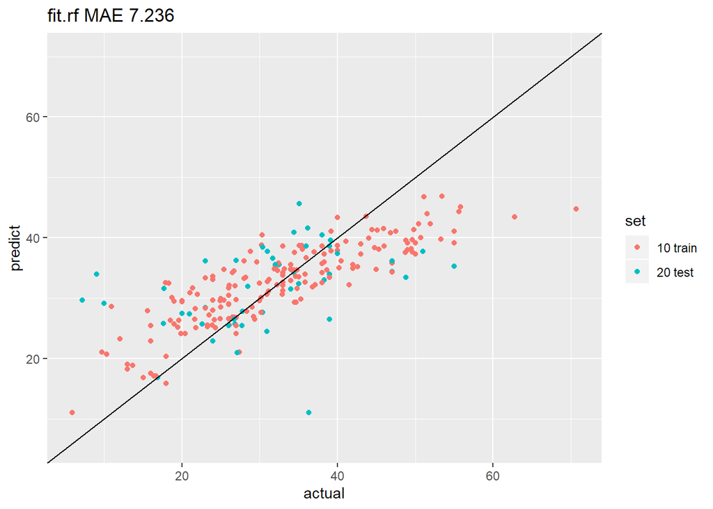

```r
show_res_all(fit.rf)
```

# neural net regression

Modelling that predicts an outcome as a function of the inputs.

```r
library(nnet)

hyper_grid <- expand.grid( size=c(15,20,30), decay = c(0,0.1))
fit.nnet <- train( form, data = train_df, method='nnet',
                   linout = 1, maxit = 50, tuneGrid = hyper_grid, trControl = fitControl)
pred.nnet <- predict(fit.nnet, newdata=test_df)[,1]
```

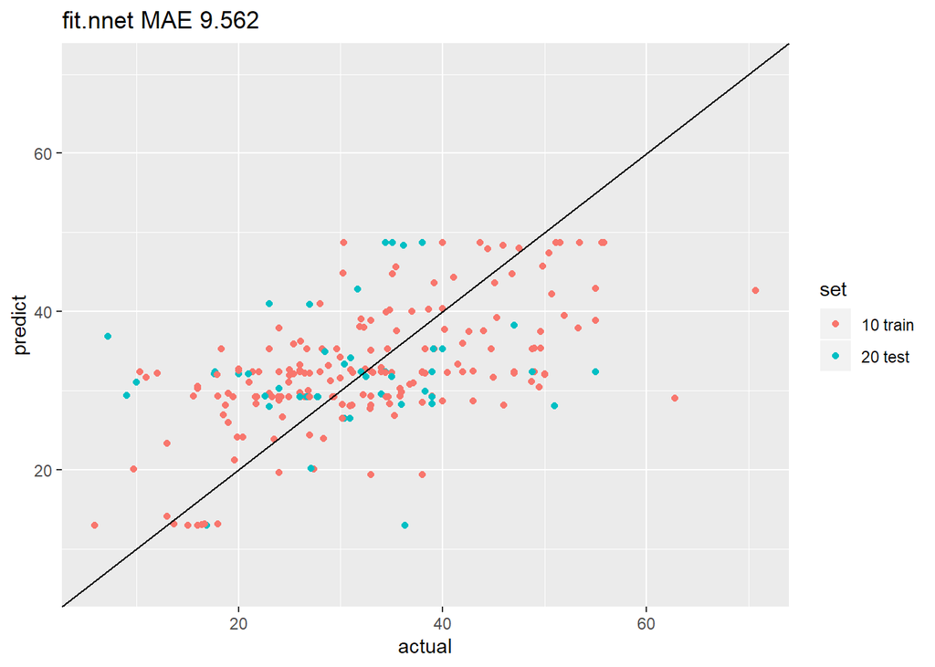

```r
show_res_all(fit.nnet)
```

# boosting

```r
fitControl <- trainControl(method = "repeatedcv", number = 10, repeats = 10,
                           verboseIter = FALSE, allowParallel = TRUE)

hyper_grid <-  expand.grid(interaction.depth = c(1, 5, 10),
                           n.trees = seq(1,10,by=5)*50,
                           shrinkage = c(0.01,0.05),
                           n.minobsinnode = c(10))

fit.gbm <- train(form, data=train_df, method = 'gbm',
                 metric = 'MAE',
                 maximize = FALSE,
                 trControl=fitControl, tuneGrid = hyper_grid,
                 verbose=FALSE)

pred.gbm <- predict(fit.gbm, newdata = test_df)
```

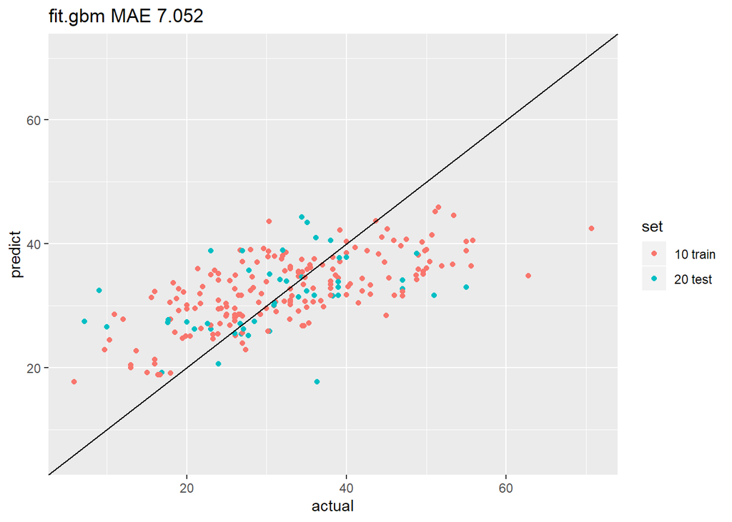

```r
show_res_all(fit.gbm)
```

# xgboost

```r
xgb_trcontrol = trainControl(
  method = "cv",
  number = 5,
  allowParallel = TRUE,
  verboseIter = FALSE,
  returnData = FALSE
)

xgbGrid <- expand.grid(nrounds = c(100,200),
                       max_depth = c(10,15,20),
                       colsample_bytree = seq(0.5, 0.9, length.out = 5),
                       ## The values below are default values in the sklearn-api.
                       eta = 0.1,
                       gamma=0,
                       min_child_weight = 1,
                       subsample = 1
)

set.seed(0)
fit.xgb = train(
  form, train_df,
  trControl = xgb_trcontrol,
  tuneGrid = xgbGrid,
  method = "xgbTree"
)

pred.xgb <- predict(fit.xgb, newdata=test_df)
```

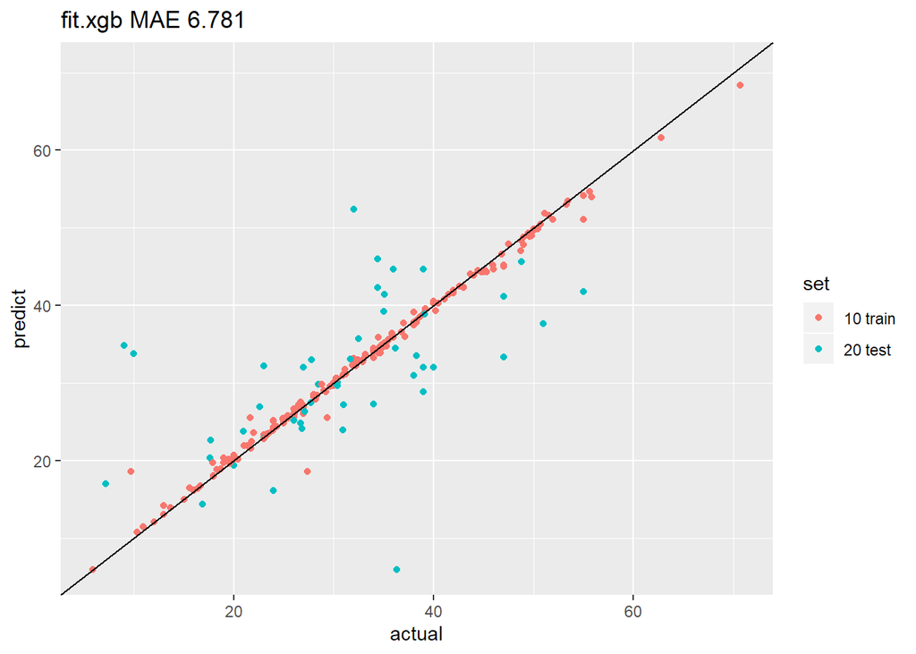

```r
show_res_all(fit.xgb)
```

# Ridge using caret

```r
set.seed(849)
fit.ridge <- train(form, train_df, method = "glmnet",
                   trControl=fitControl,preProc = c("center","scale"),
                   tuneGrid = expand.grid(alpha = 0,
                                          lambda = 0))
pred.ridge <- predict(fit.ridge,newdata=test_df)
```

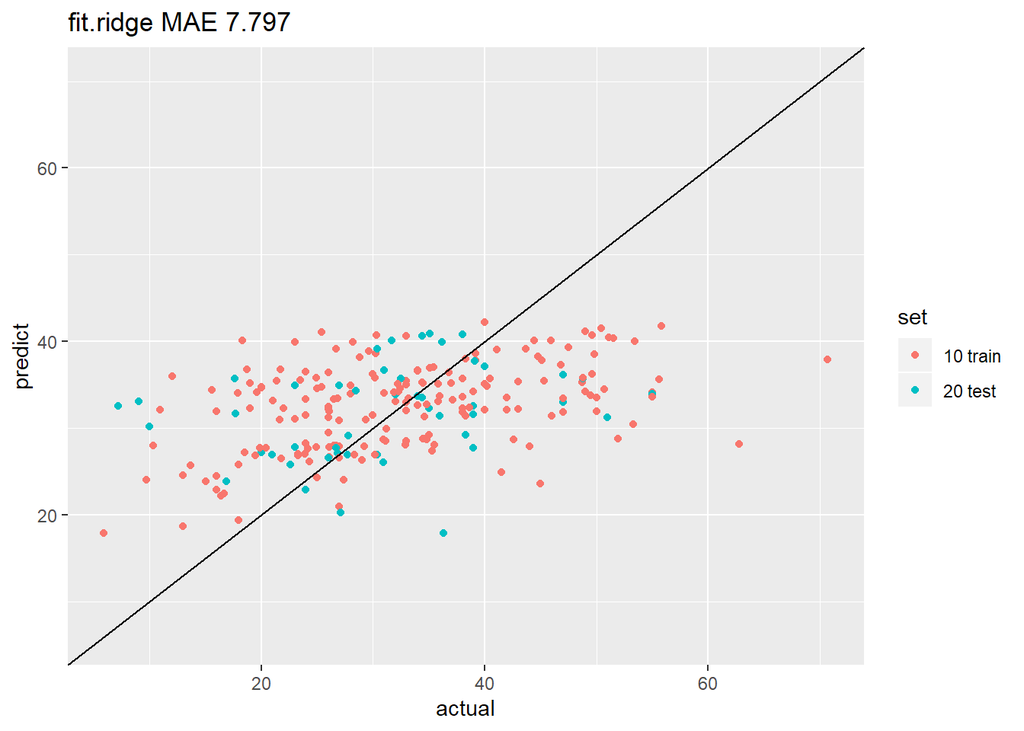

```r
show_res_all(fit.ridge)
```

# Lasso

```r
set.seed(849)
fit.lasso<- train(form, train_df, method = "glmnet",
                  trControl=fitControl,preProc = c("center","scale"),
                  tuneGrid = expand.grid(alpha = 1,
                                         lambda = 0))
pred.lasso <- predict(fit.lasso,newdata=test_df)
```

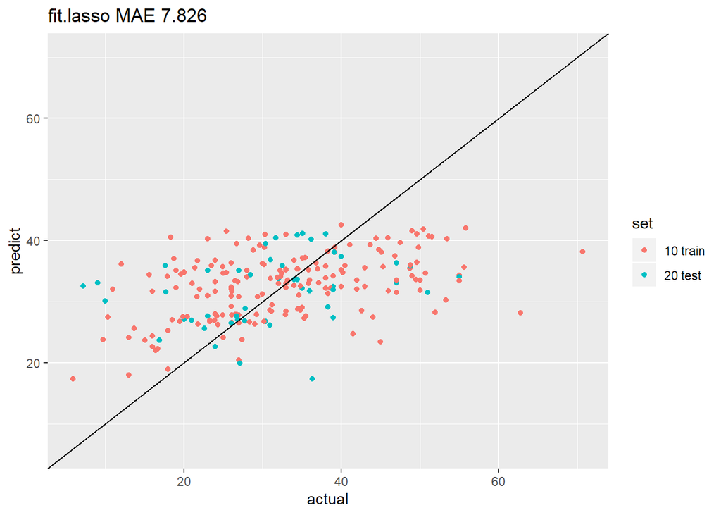

```r
show_res_all(fit.lasso)
```

# Keras Neural Network

Keras Deep Neural Net 을 이용해서 모델링을 한다. 먼저 *keras* 를 인스톨 해야 한다.

다음에 팩터 변수들을 임베딩 처리한다. - 팩터의 경우 one-hot encoding 하면 되지만 갯수가 많을경우 overfitting 문제가 있다 - 그래서 팩터들을 one-hot 으로 바꾼 후, 이를 다시 더 낮은 차원으로 임베딩한다 - 임베딩 방법은 직접 예측할 변수를 피팅하고, 그 중간 레이어의 변수를 이용하거나 - 또는 autoencoder 를 만들어서 사용한다

- 팩터의 값 갯수가 *embed_cutoff* 보다 크면 임베딩 한다
- 임베딩은 팩터값 갯수/2 혹은 *embed_min_dim* 중에 큰 것으로 한다
- 임베팅 학습의 반복은 *iter* 로 지정한다.
- 임베딩 방법은 *embed_method* 로 지정한다

```r
library(keras)

embed_cutoff <- 10
embed_min_dim <- 10
embed_mat <- NULL
embed_iter <- 10
embed_fit_target <- as.numeric(df0[,response])
embed_method <- 'autoencoder'
```

전체 변수에 대해 수치형은 그대로, 값의 갯수가 적은 팩터는 one-hot encoding 으로 데이터를 만든다.

````r
for(var in names(df0)){

  if(var == response) next
  if(class(df0[,var]) == 'character') df0[,var] <- factor(df0[,var])

  if(class(df0[,var]) %in% c('integer', 'numeric')){
    cat('Numeric :',var,'\n')
    embed_mat1 <- df0[,var,drop=F]
    if(is.null(embed_mat)) embed_mat <- embed_mat1 else embed_mat <- cbind(embed_mat, embed_mat1)
    next
  }

  nunique <- length(unique(df0[,var]))

  if(nunique <= embed_cutoff){
    cat('Factor : Accept',var,'\n')
    embed_mat1 <- to_categorical(as.numeric(df0[,var,drop=TRUE])-1)
    colnames(embed_mat1) <- paste0(var,'_',1:ncol(embed_mat1))
    embed_mat <- cbind(embed_mat, embed_mat1)
    next
  }
#  ```
#
#  그렇지 않은 경우 임베딩을 한다. 피팅의 경우는 피팅하는 중간의 레이어에서 임베딩을 가져온다
#  ```{r}
  cat('Factor : Embed',var,'\n')

  embed_var <- var
  input_size <- length(unique(df0[,embed_var]))
  embedding_size <- max(embed_min_dim,min(input_size/2,50))

  if(embed_method == 'fit'){
    # method 1. fit
    model <- keras_model_sequential()
    model %>%
      layer_embedding(input_dim = input_size, output_dim = embedding_size, input_length = 1, name = paste0('emb_',embed_var)) %>%
      layer_flatten() %>%
      layer_dense(units=40,activation='relu') %>%
      layer_dense(units=10,activation='relu') %>%
      layer_dense(units=1)

    model %>% compile(loss='mse',optimize='sgd',metric='accuracy')
    dummyX <- to_categorical(as.numeric(df0[,embed_var])-1)

    hist <- model %>% fit(x=dummyX,y=embed_fit_target, epochs = embed_iter, batch_size = 2)
    layer <- get_layer(model,paste0('emb_',embed_var))
    embed_coef <- data.frame(layer$get_weights()[[1]])
    name <- levels(df0[,embed_var])
    apply(embed_coef,2,sd)
    ggplot(embed_coef) + geom_point(aes(X4,X5,color=name)) + guides(color=FALSE) + geom_text(aes(X4,X5,label=name))
    embed_mat1 <- to_categorical(dummyX) %*% as.matrix(embed_coef)
#   ```
#
#    autoencoder 로 하는 경우, 중간 레이어에서 가져온다
#
#    ```{r}
  } else {
    # method 2. autoencoder
    model <- keras_model_sequential()
    model %>%
      layer_dense(units = embedding_size*2, activation='tanh', input_shape = input_size) %>%
      layer_dense(units = embedding_size, activation='tanh', name=paste0('emb_',embed_var)) %>%
      layer_dense(units = embedding_size*2, activation='tanh') %>%
      layer_dense(units = input_size)

    model %>% compile(loss = 'mse',optimizer='adam')
    dummyX <- to_categorical(as.numeric(df0[,embed_var])-1)
    model %>% fit(x=dummyX, y=dummyX, epochs=embed_iter, batch_size=32)
    embed_model <- keras_model(inputs=model$input,outputs=get_layer(model,paste0('emb_',embed_var))$output)
    embed_mat1 <- predict(embed_model,dummyX)
  }
  colnames(embed_mat1) <- paste0(embed_var,1:ncol(embed_mat1))

  embed_mat <- cbind(embed_mat, embed_mat1)
}
````

```
## Factor : Accept Type
## Numeric : Diameter
## Numeric : Length
## Factor : Accept GeoCondition
```

전체 데이터를 하나로 합치고 여기서 위에서 구한 인덱스를 이용해서 학습 및 테스트 셋을 나눈다

```r
embed_mat <- as.matrix(embed_mat)
train_data <- embed_mat[train.idx,]
train_labels <- df0[train.idx, response]
test_data <- embed_mat[test.idx,]
test_labels <- df0[test.idx,response]
```

```r
save(file='keras_regression.RData',embed_mat,train_data,train_labels,test_data,test_labels)
```

```r
build_model <- function() {

  model <- keras_model_sequential() %>%
    layer_dense(units = 64, activation = "relu",
                input_shape = dim(train_data)[2]) %>%
    layer_dropout(0.2) %>%
    layer_dense(units = 64, activation = "relu") %>%
    layer_dropout(0.2) %>%
    layer_dense(units = 16, activation = "linear") %>%
    layer_dense(units = 1)

  model %>% compile(
    loss = "mae",
    optimizer = optimizer_rmsprop(),
    metrics = list("mean_absolute_error")
  )

  model
}

model <- build_model()
```

```r
model %>% summary()
```

```
## ___________________________________________________________________________
## Layer (type)                     Output Shape                  Param #
## ===========================================================================
## dense (Dense)                    (None, 64)                    768
## ___________________________________________________________________________
## dropout (Dropout)                (None, 64)                    0
## ___________________________________________________________________________
## dense_1 (Dense)                  (None, 64)                    4160
## ___________________________________________________________________________
## dropout_1 (Dropout)              (None, 64)                    0
## ___________________________________________________________________________
## dense_2 (Dense)                  (None, 16)                    1040
## ___________________________________________________________________________
## dense_3 (Dense)                  (None, 1)                     17
## ===========================================================================
## Total params: 5,985
## Trainable params: 5,985
## Non-trainable params: 0
## ___________________________________________________________________________
```

```r
# 중간에 점 찍기
print_dot_callback <- callback_lambda(
  on_epoch_end = function(epoch, logs) {
    if (epoch %% 80 == 0) cat("\n")
    cat(".")
  }
)
```

```r
epochs <- 1000

# Fit the model and store training stats
history <- model %>% fit(
  train_data,
  train_labels,
  epochs = epochs,
  validation_split = 0.2,
  verbose = 1,
  callbacks = list(print_dot_callback)
)
```

```
##
## ................................................................................
## ................................................................................
## ................................................................................
## ................................................................................
## ................................................................................
## ................................................................................
## ................................................................................
## ................................................................................
## ................................................................................
## ................................................................................
## ................................................................................
## ................................................................................
## ........................................
```

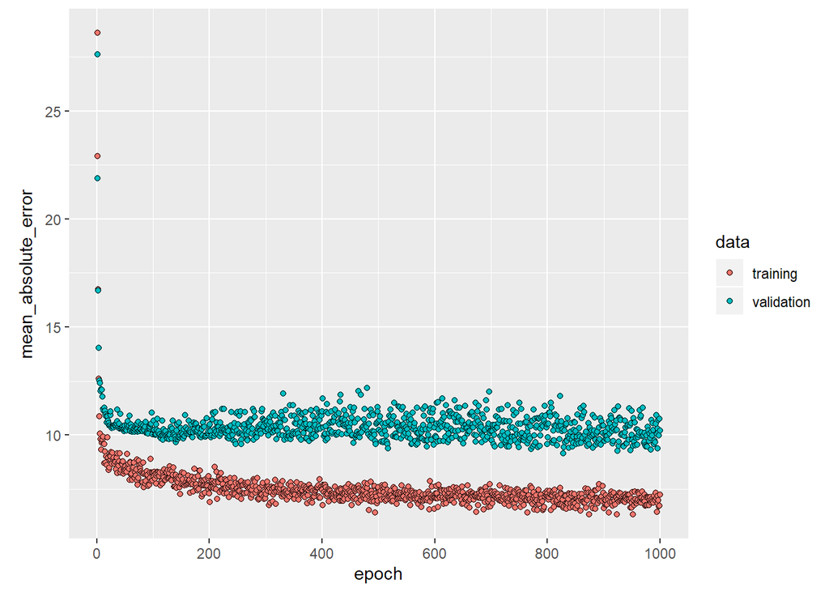

```r
plot(history, metrics = "mean_absolute_error", smooth = FALSE) +
  coord_cartesian()
```

```r
c(loss, MAE) %<-% (model %>% evaluate(test_data, test_labels, verbose = 0))
```

```r
paste0("Mean absolute error on test set:", sprintf("%.2f", MAE ))
```

```
## [1] "Mean absolute error on test set:8.84"
```

```r
pred.keras <- (model %>% predict(test_data))[,1]
```

```r
plot(actual, pred.keras)
mean(abs(actual-pred.keras))
```

```
## [1] 8.842578
```

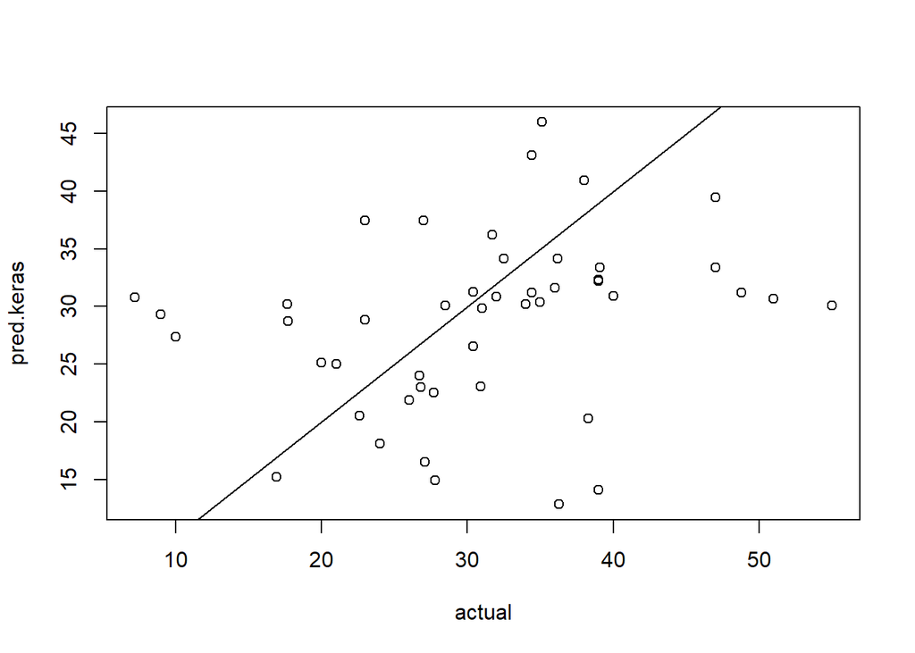

```r
abline(0,1)
```

# Summary

pred.* 변수들을 한데 모은다

```r
vars <- ls()
predvars <- vars[grepl('^pred\\.',vars)]
results <- sapply(predvars,get)
colnames(results) <- predvars
```

실제값과의 차이를 구한다

```r
resid <- sweep(results,1,actual)
```

성능지표들의 평균값과 중간값 구하기

```r
result_summary <- function(df, base_df, fun){
  data.frame(
    bias = apply(df,2,fun),
    mae = apply(abs(df),2,fun),
    rmse = sqrt(apply(df^2,2,fun)),
    mape = apply(abs(df/base_df),2,fun))
}

fit.result.means <- result_summary(resid, results, mean)
fit.result.medians <- result_summary(resid, results, median)
```

모델별 지표 비교. lm 계열의 결과들은 Cross Validation 한 것이 아니고, 전체 데이터에 대한 모델링 (학습에 대한 에러) 만 나온 것임.

모델별 평균값

```r
DT::datatable( round(fit.result.means,4), caption='Metric - Mean values',options = list(pageLength = 20))
```

|  | bias | mae | rmse | mape |
| --- | --- | --- | --- | --- |
| pred.gbm | 0.6188 | 7.0517 | 9.456 | 0.2312 |
| pred.keras | -2.2011 | 8.8426 | 11.2943 | 0.3571 |
| pred.lasso | 0.965 | 7.826 | 10.2813 | 0.2543 |
| pred.lm | 0.8674 | 7.293 | 9.4978 | 0.2353 |
| pred.lm.opt | 1.332 | 7.6899 | 9.5714 | 0.2538 |
| pred.mars | 0.0131 | 8.16 | 10.4619 | 0.2931 |
| pred.nnet | 1.4698 | 9.5619 | 11.868 | 0.3144 |
| pred.reg | 0.7395 | 9.4961 | 12.4977 | 0.9296 |
| pred.rf | 0.8992 | 7.236 | 9.8378 | 0.2562 |
| pred.ridge | 0.9413 | 7.7967 | 10.2571 | 0.2527 |

[output cut: 4 more lines]

모델별 중간값

```r
DT::datatable( round(fit.result.medians,4), caption='Metric - Median Values',options = list(pageLength = 20))
```

|  | bias | mae | rmse | mape |
| --- | --- | --- | --- | --- |
| pred.gbm | -0.5119 | 4.7545 | 4.7545 | 0.1665 |
| pred.keras | -3.2165 | 5.8794 | 5.8794 | 0.205 |
| pred.lasso | 0.9379 | 6.0577 | 6.0577 | 0.1833 |
| pred.lm | 0.4981 | 5.2379 | 5.2379 | 0.1639 |
| pred.lm.opt | 2.0688 | 5.8991 | 5.8991 | 0.18 |
| pred.mars | -0.6268 | 6.5129 | 6.5129 | 0.2218 |
| pred.nnet | 1.5438 | 7.7856 | 7.7856 | 0.2517 |
| pred.reg | 1.7194 | 7.243 | 7.243 | 0.2134 |
| pred.rf | -0.0208 | 5.4124 | 5.4124 | 0.1589 |
| pred.ridge | 0.9971 | 5.9587 | 5.9587 | 0.1859 |

[output cut: 4 more lines]